# DRIP: An R Package for Jump Regression and Image Analysis

Jump regression performs nonparametric regression analysis where the regression function can be discontinuous. Because of its ability to conduct jump detection and jump-preserving estimation, jump regression provides a natural statistical framework for image analysis. It enables statistical inference involved in many image processing problems including edge detection, image denoising and image deblurring. As the jump regression literature grows over the past two decades, the methodological development has far outpaced the availability of jump regression software. Although there are many image processing software programs, most of them implement either generic image operations or statistical analysis of images of specific types. In this article, we introduce DRIP, an R package with a number of state-of-the-art jump regression methods for jump detection and surface reconstruction. Its open-source nature and user-friendly interface make it convenient to develop and evaluate jump regression methods, encouraging wider adoption and future research. Although the current version of DRIP supports analysis of monochrome images only, as the literature on multivariate jump regression is still lacking, our methods can be applied separately to each color channel when handling color images.

Yicheng Kang https://miamioh.edu/fsb/directory/?up=/directory/kangy10 (Miami University)  
2026-09-30

## 1 Introduction

Rapid development in image acquisition technology has made images widely available in engineering, scientific research and everyday life. Because of their ability to capture spatial patterns and geometric information, images play increasingly important roles in areas such as astronomy, medical imaging, microscopy, motion tracking, optics, photography, and remote sensing, among others. Since image data are unstructured in nature and may contain measurement errors, analyzing images requires special techniques. In remote sensing, for instance, satellite images, which are often used in landscape monitoring, are affected by atmospheric noise due to light reflection from aerosols and clouds (Boonprong et al. 2018). In such cases, noise removal, i.e., image denoising (Polzehl and Spokoiny 2000; Buades et al. 2005), may be necessary before any subsequent analysis. In medical diagnostics, magnetic resonance imaging (MRI) is used for measuring tumor growth in cancer patients. Images taken at different times may be misaligned because of the difference in the relative position between the patient and the imaging device. Meaningful comparison of the images for quantifying changes in tumor size cannot be done before geometrically matching up the images (Klein et al. 2009), a technique known as image registration (Zitova and Flusser 2003). In photography, camera shake causes motion blur in images (Bai et al. 2018), making tasks such as recognizing objects in the image difficult. In such situations, a number of image deblurring techniques can be useful, e.g., Bayesian-based deblurring (Wang et al. 2011), diffusion-based deblurring (Yue et al. 2025) and deep learning-based deblurring (Quan et al. 2024).

There are a number of choices of software that implement various image processing techniques. MATLAB (The MathWorks Inc 2023) includes an image processing toolbox with many useful tools for general-purpose image processing. A nice feature of MATLAB is that it has a built-in parallel computing toolbox to offer high-speed processing. In recent years, it has been expanded to support graphics processing unit (GPU) acceleration for some of its image processing functions (Georgantzoglou et al. 2014). A major limitation of MATLAB is that its commercial licensing can limit its large-scale adoption by practitioners. In particular, the licensing cost increases significantly for parallel computing, with per-worker pricing. Additionally, MATLAB’s closed-source nature prevents users from modifying code for prototyping new methods, a common undertaking in scientific research. Among the open-source options, OpenCV (Bradski and Kaehler 2008) is a comprehensive library for computer vision. It is traditionally written in C with most new algorithms developed in C++. As a result, OpenCV offers fast execution. Because of the same reason, it is more difficult for users to modify its code. More recently, OpenCV has added a Python interface to attract wider adoption. As an alternative to OpenCV, scikit-image (Van der Walt et al. 2014), written completely in Python, is an open-source library that provides users with easy access to algorithms for image processing. It offers a wide array of generic image operations such as image cropping, image resizing, and conversion between color and grayscale images. With the rising popularity of Python, scikit-image has seen significant growth in both adoption and contribution. Although favored by computer scientists, Python remains less popular than R (R Core Team 2023) in the statistics community who are accustomed to R’s rich ecosystem of complex statistical models. A number of R packages for image processing are available. Some of them are for general image processing. For example, the [EBImage](https://www.bioconductor.org/packages/EBImage/) package (Pau et al. 2010) provides general functionality for the reading, writing, processing and analysis of images. The adimpro package (Polzehl and Tabelow 2007) and aws package (Polzehl et al. 2020; Polzehl and Tabelow 2023) implement tools for manipulation of digital images and adaptive image denoising. The OpenImageR package (Mouselimis 2023) offers functions for image filtering too. Its recent update allows the Rcpp functions of the OpenImageR package to be called in the C++ files of another package. Some other packages focus on images of certain types. For example, the dti package described in Tabelow et al. (2008) and Tabelow and Polzehl (2011) handles diffusion weighted imaging data with methods for structural adaptive smoothing and fiber tracking for tensor and tensor mixture models. The landsat package suggested in Goslee (2023) and Goslee (2011) provides radiometric and topographic correction routines for satellite imagery.

These existing image processing software either implement generic operations or carry out special-purpose analysis of images in specific categories. None of them has implemented methods in jump regression (Qiu 2005), a general regression framework for image analysis. A major benefit with jump regression methods is that it enables statistical inference, such as surface estimation, standard error calculation and data-driven parameter selection, in many image processing problems including edge detection (Sun and Qiu 2007), image denoising (Gijbels et al. 2006) and image deblurring (Hall and Qiu 2007). The R package DRIP is created to fill this gap. Specifically, it implements two-dimensional jump regression methods with an emphasis on image processing applications. Regarding its computational performance, some of DRIP’s source code, large loops in particular, are written in Fortran or C to offer high execution speed. Parallel computing is also enabled in several routines to gain further acceleration. On the other hand, with the R interface, functions in DRIP are convenient to use, and their outputs are easy to visualize. As for its limitations, DRIP currently only supports analysis of grayscale images. This is because the existing jump regression literature has only considered cases of univariate responses. Much research is still needed on multivariate jump regression. As a practical workaround, our methods can be applied separately to each color channel when handling color images.

## 2 Package overview

The DRIP package provides functionality for three categories of image analysis problems: edge detection, edge-preserving noise removal and blind image deblurring. Edge detection is often used in image data compression. The following functions in the package are related to the task of edge detection: `stepEdge`, `roofEdge`, `dKQ`, `modify1` and `modify2`. Noise removal and image deblurring are important for improving human and machine perception of the images. The `JPLLK_surface`, `surfaceCluster` and `threeStage` functions in the package are related to noise removal. The `jpex` and `cv.jpex` functions are related to image deblurring. Furthermore, the package is designed for general image analysis without restrictions on the specific image type. However, the current use of DRIP focuses on grayscale images only, due to the aforementioned limitation in the jump regression literature. To use DRIP in practice, the workflow often involves parameter tuning before model estimation. This intended workflow is illustrated in the section of Workflow Illustration.

The remaining part of this article is organized as follows. Section 3 gives a short primer on 1-dimensional jump regression. Section 4 introduces 2-dimensional jump regression models, the related terminologies and their connections with image processing techniques. Section 5 describes edge detection routines in DRIP. Section 6 discusses methods included in the package for edge-preserving surface reconstruction from noisy images. Section 7 describes the problem of image deblurring and a blind deblurring algorithm in DRIP. Section 8 illustrates the workflow of using DRIP. Section 9 concludes the article and suggests future work.

## 3 A jump regression primer

One significant application of jump regression is image processing where the regression function $f(\cdot, \cdot)$ is 2-dimensional. In such cases, the jump positions form jump location curves, and there are infinitely many directions for defining one-sided limits of $f$. Consequently, it becomes more complex to construct one-sided estimates in 2-dimensional jump regression. However, the fundamental idea of jump-preserving estimation remains the same: estimate the regression surface by one-sided smoothing at jump points and conventional smoothing at continuity points. The next section discusses in more detail the connection between 2-dimensional jump regression and digital image representation.

## 4 Image representation and jump regression models

Images generated by various devices such as cameras, scanners and sensors capture the spatial and amplitude behavior of the related physical scene. The spatial location is described by the x- and y- coordinates. The amplitude behavior is described by the amounts of illumination. The amplitude of color images consists of three channels: red, green and blue. For grayscale images, the amplitude is only a scalar, also known as intensity or gray level. In our discussion, all images are grayscale unless mentioned otherwise.

Images can be continuous with respect to the spatial coordinates and amplitude. In order for computers to handle an image, the image needs to be digitized. The process of digitizing the spatial location of an image is referred to as *sampling* (Gonzalez and Woods 2018). It takes equally spaced x- and y- coordinates and represents the image by a matrix $\{f(x_i, y_j): i = 1, \ldots, n_1, j = 1, \ldots, n_2 \}$. Each $f(x_i, y_j)$, the amplitude value at location $(x_i, y_j)$, is called a pixel of the image. The sample size $n_1 \times n_2$ is the image resolution. It is noteworthy that popular image processing software programs (e.g., MATLAB) have the origin of the spatial coordinates at the upper-left corner of the image with the x-axis going vertically downward and the y-axis going horizontally to the right. In R and thus with DRIP, however, the spatial coordinates of an image have their origin at the lower-left corner of the image, with the x-axis going horizontally to the right and the y-axis going vertically upward. In addition to digitizing the spatial location, image digitization also requires converting the intensity values into discrete quantities, a process often referred to as *quantization* (Qiu 2005). Conventionally, $f(x_i, y_j)$ is discretized to be an integer in the range $[0, M - 1]$, where $M$ is an integer power of $2$. For instance, if $M = 2^8$, then a single pixel takes one byte in computer storage. Clearly, the quality of a digital image is affected by the sampling resolution and number of levels (i.e., $M$) used in quantization.

```r
library(DRIP)
data("peppers")
data("sar")
```

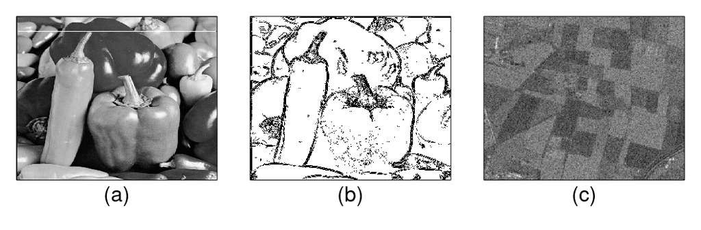

Figure 1: (a) The test image of peppers. (b) The boundary curves in the peppers image. (c) A SAR image of an area near Thetford forest, England.

In image processing, jump locations in $f$ are called *step edges*, and jump locations in the first-order derivatives of $f$ are called *roof edges*. Therefore, edge detection and edge-preserving image restoration in image processing are essentially the same tasks as jump detection and jump-preserving surface estimation in jump regression. However, jump regression is more general in two regards. First, image pixels are equally spaced, but jump regression model (1) does not require this regularity. The design points can be arbitrarily distributed and the design space $\Omega$ can be of any shape. This flexibility can be useful in some applications such as the estimation of equi-temperature surfaces in meteorology and oceanography (Kang et al. 2021). Second, intensity values of a digital image are discrete, and some image processing techniques make use of this discreteness, rendering them inappropriate for handling certain jump regression problems. By contrast, jump regression treats $Z_{i,j}$ in (1) as a numerical response and does not share this limitation. To facilitate our discussion in the remainder of this article, we assume that $n_1 = n_2$, $\Omega = [0, 1] \times [0, 1]$, and $\{\varepsilon_{i, j} \}$ are i.i.d. random errors with mean 0 and variance $\sigma^2$. In the following sections, we describe some jump regression methods and their implementations in DRIP.

## 5 Estimation of jump location curves

### 5.1 Step edge detection

First, we briefly describe the step edge detection method proposed in Kang and Qiu (2014). For any given point $(x, y) \in \Omega$, consider its circular neighborhood,
$$\begin{align*}
O(x, y; h) = \left\{(u, v) \in \Omega: (x - u)^2 + (y - v)^2 \leq h^2 \right\},
\end{align*}$$
where $h > 0$ is a bandwidth parameter, and the following local linear kernel smoothing procedure:
$$\begin{align}
\tag{2}
\min_{a, b, c} \sum_{(x_i, y_j) \in O(x, y; h)} \left\{ Z_{i, j} - [a + b(x_i - x) + c(y_j - y)] \right\}^2 K_{i, j},
\end{align}$$
where $K_{i, j} = K((x_i - x)/h, (y_j - y)/h)$ and $K$ is a circularly symmetric bivariate density kernel function defined on the unit disk centered at the origin. The solution to $(b, c)$ in (2), denoted by $(\widehat{b}(x, y), \widehat{c}(x, y))$, estimates the gradient of $f$ at $(x, y)$. If $(x, y)$ is near a jump location curve, $(\widehat{b}(x, y), \widehat{c}(x, y))$ indicates the direction in which $f$ increases the fastest, i.e., orthogonal to the jump location curve’s tangent. Based on this intuition, we divide $O(x, y; h)$ into two halves along the direction perpendicular to $(\widehat{b}(x, y), \widehat{c}(x, y))$. Specifically, define (as illustrated in Figure 2)
$$\begin{align*}
O_{1}(x, y) &= \left\{ (x_i, y_j) \in O(x, y; h): (x_i - x) \widehat{b}(x, y) + (y_j - y) \widehat{c}(x, y) \geq 0 \right\}, \\
O_{2}(x, y) &= \left\{ (x_i, y_j) \in O(x, y; h): (x_i - x) \widehat{b}(x, y) + (y_j - y) \widehat{c}(x, y) < 0 \right\}.
\end{align*}$$

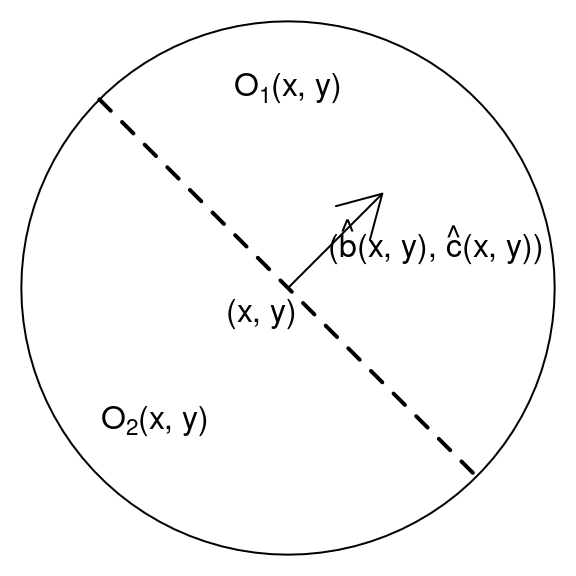

Figure 2: Neighborhood $O(x, y; h)$ of the design point $(x, y)$ is divided into two halves $O_1(x, y)$ and $O_2(x, y)$ along the direction perpendicular to the estimated gradient $(\widehat{b}(x, y), \widehat{c}(x, y))$.

The change in the values of $f$ from $O_2(x, y)$ to $O_1(x, y)$ should be relatively large if $(x, y)$ is a jump point. To estimate this change, we fit two local linear kernel smoothing procedures in $O_1(x, y)$ and $O_2(x, y)$:
$$\begin{align}
\min_{a_1, b_1, c_1} & \sum_{(x_i, y_j) \in O_1(x, y)} \left\{ Z_{i, j} - [a_1 + b_1(x_i - x) + c_1(y_j - y)] \right\}^2 K_{i, j}, \tag{3} \\
\min_{a_2, b_2, c_2} & \sum_{(x_i, y_j) \in O_2(x, y)} \left\{ Z_{i, j} - [a_2 + b_2(x_i - x) + c_2(y_j - y)] \right\}^2 K_{i, j}. \tag{4}
\end{align}$$
The solutions to $a_1$ of (3) and $a_2$ of (4) are denoted as $\widehat{f}_{+}(x, y)$ and $\widehat{f}_{-}(x, y)$, respectively. The design point $(x, y)$ is flagged as a detected jump point if
$$\begin{align}
\tag{5}
\left| \widehat{f}_{+}(x, y) - \widehat{f}_{-}(x, y) \right| > u,
\end{align}$$
where $u$ is a threshold parameter. This step edge detector is implemented by the `stepEdge` function, illustrated as follows.

```r
stepedge <- stepEdge(image = sar, bandwidth = 10, thresh = 17,
                     degree = 1)
```

The output of `stepEdge` is a matrix of 0’s and 1’s. Figure 3(a) shows the estimated step edges by the function `stepEdge`. Here the parameter values of the bandwidth and threshold are user-specified. The data-driven parameter selection is discussed later in this section. It is worth noting that the bandwidth is specified in terms of the number of pixels. Also, we have exchanged 0’s and 1’s in the visualization with the `image` function in order to have the jump points shown in black.

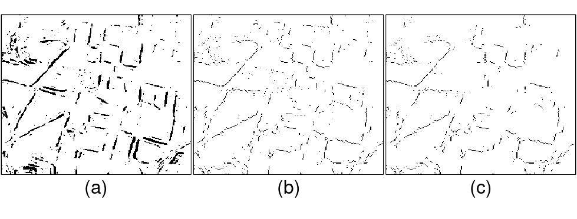

Figure 3: (a) The estimated step edges of SAR produced by `stepEdge`. (b) The estimated step edges after the first modification procedure described in the subsection of Two Modification Procedures. (c) The estimated step edges after the two modification procedures.

Next, we compare our step edge detector `stepEdge` with the classic Sobel edge detector implemented by the function `edge_detection` in the OpenImageR package. The Sobel edge detector estimates the partial derivatives using two $3\times 3$ Sobel masks and outputs the magnitude of the estimated gradient. In Figure 4, we apply both edge detectors to a test image of peppers and its noisy version. The noise is generated from the normal distribution $N(0, 30^2)$. It can be seen from the figure that the two edge detectors have rendered comparable results for the original test image, but the Sobel edge detector has produced many scattered false signals for the noisy version. This is because the Sobel edge detector has masks of fixed size. By contrast, `stepEdge` can adjust the bandwidth value (i.e., the neighborhood size) to accommodate different levels of noise. Additionally, the Sobel edge detector does not generate the binary output of edge detection. We have used the `90%` quantile as the threshold. In comparison, DRIP offers data-driven selection of the bandwidth and threshold parameters in `stepEdge`, which is described next.

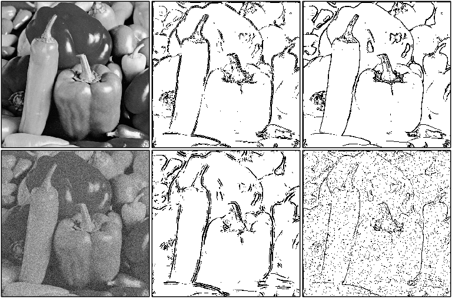

Figure 4: A comparison with the Sobel edge detector (from left to right). Top row: a test image of peppers, the edges detected by `stepEdge` and the edges detected by Sobel. Bottom row: a noisy version of the peppers image and the detected edges by `stepEdge` and Sobel.

```r
edge_peppers <- stepEdge(image = peppers, bandwidth = 5, thresh = 14, degree = 1)
sobel_peppers <- edge_detection(image = peppers, method = "Sobel")
par(mfrow = c(2, 3), mar = c(0.1, 0.1, 0.1, 0.1), xaxt = "n", yaxt = "n")
image(peppers, col = gray(c(0:255)/255))
image(1 - edge_peppers, col = gray(c(0:255)/255))
image(sobel_peppers < quantile(sobel_peppers, 0.9), col = gray(c(0:255)/255))
set.seed(42)
noise <- matrix(rnorm(prod(dim(peppers)), mean = 0, sd = 30),
                nrow = nrow(peppers), ncol = ncol(peppers))
edge_peppers <- stepEdge(image = peppers + noise, bandwidth = 11, thresh = 28,
                         degree = 1)
sobel_peppers <- edge_detection(image = peppers + noise, method = "Sobel")
image(peppers + noise, col = gray(c(0:255)/255))
image(1 - edge_peppers, col = gray(c(0:255)/255))
image(sobel_peppers < quantile(sobel_peppers, 0.9), col = gray(c(0:255)/255))
```

In order to properly select parameters for edge detection, Kang and Qiu (2014) has suggested the following performance measure for edge detectors.
$$\begin{align}
d_{KQ}(\widehat{S}, S; h, u) =& \frac{1}{2| \widehat{S} |} \sum_{(x^\prime, y^\prime) \in \widehat{S}} d_E\left((x^\prime, y^\prime), S \right) \nonumber \\
&+ \frac{1}{2\left| S \right|} \sum_{(x, y) \in S} d_E\left((x, y), \widehat{S} \right), \tag{6}
\end{align}$$
where $d_E(\cdot, \cdot)$ denotes the Euclidean distance, and $S$ and $\widehat{S}$ are the true and estimated step edge points respectively. Here the Euclidean distance between a point $(x^\prime, y^\prime)$ and a set $S$ is defined to be $d_E((x^\prime, y^\prime), S) = \inf_{(x, y) \in S} d_E((x^\prime, y^\prime), (x, y))$. The first term in (6) includes all falsely detected jump points and calculates their average distance from $S$. The second term includes all missed true jump points and calculates their average distance from $\widehat{S}$. If $\widehat{S} = S$, we have $d_{KQ} = 0$. In practice, however, the true jump locations are unknown and thus $d_{KQ}$ cannot be computed. To address this issue, a bootstrap version of (6), denoted by $\widehat{d}_{KQ}(\widehat{S}, S; h, u)$, is proposed in Kang and Qiu (2014). It works as follows.

Bootstrap Procedure for Selecting $h$ and $u$

1. Apply the jump detector `stepEdge` to the original data set $\{(x_i,y_j,Z_{i,j}), i,j = 1, \ldots, n\}$. The set of detected jump points is denoted as $\widehat{S}$.
2. Apply a jump-preserving surface estimator and obtain $\widehat{f}(x,y)$. Define the residuals by $\widehat{\varepsilon}_{i, j} = Z_{i, j} - \widehat{f}(x_i, y_j)$.
3. Draw with replacement a bootstrap sample of size $n^2$, denoted as $\{\widehat{\varepsilon}^*_{i, j}, i, j = 1, \ldots, n\}$, from the residual set $\{\widehat{\varepsilon}_{i, j}, i, j = 1, \ldots, n\}$, and then obtain a bootstrap data set $\{(x_i, y_j, Z^*_{i, j}), i, j = 1, \ldots, n\}$, where $Z^*_{i, j} = \widehat{f}(x_i, y_j) + \widehat{\varepsilon}^*_{i, j}$.
4. Apply the jump detector with the same bandwidth and threshold as that in step 1  
   to the bootstrap data set, and obtain a set of detected jump points from this bootstrap data.
5. Repeat step 3 and 4 for $B$ times. The sets of the detected jump points from the $B$ bootstrap data sets are denoted as $\widehat{S}^*_{1}, \widehat{S}^*_{2}, \ldots,\widehat{S}^*_{B}$, respectively. Then, the bootstrap estimator of $d_{KQ}(\widehat{S}, S; h, u)$ is defined by
   $$\widehat{d}_{KQ}(\widehat{S},S; h, u)=
   \frac{1}{B}\sum_{b=1}^B d_{KQ}(\widehat{S}^*_{b},\widehat{S}; h, u).$$
   The optimal bandwidth and threshold values are then approximated by the minimizer of $\widehat{d}_{KQ}(\widehat{S}, S; h, u)$ with respect to $(h, u)$:
   $$\begin{align*}
   \min_{h \in \mathscr{H}, u \in \mathscr{U}} \widehat{d}_{KQ}(\widehat{S}, S; h, u),
   \end{align*}$$
   where $\mathscr{H}$ and $\mathscr{U}$ are candidates for the two parameters given by users.

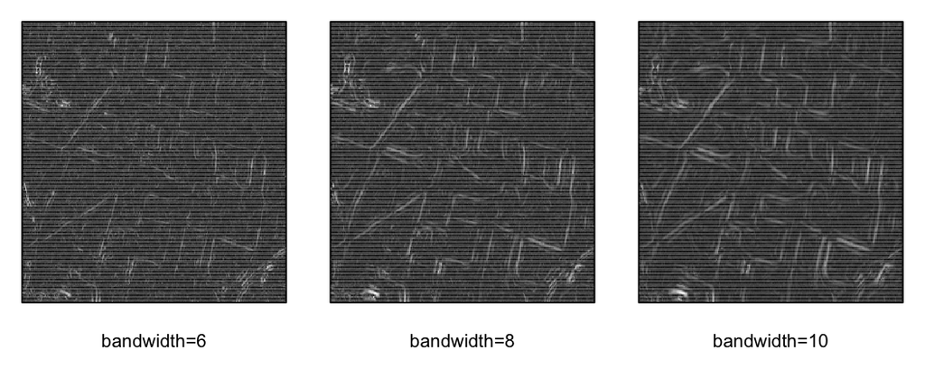

Figure 5: The images of the edge detection statistics for specified bandwidths.

```
             probs=0.75 probs=0.85 probs=0.95
bandwidth=6   10.688440   13.79875   20.18085
bandwidth=8    9.610952   12.59395   19.38523
bandwidth=10   9.226387   12.21794   19.25910
```

```r
edgeParSelPilot(sar, edgeType = "step", degree = 1,
                bandwidth = c(6, 8, 10), probs = c(0.75, 0.85, 0.95))
```

Based on the visual impression given by Figure 5, bandwidth values around 10 seem reasonable as the visualization is less noisy. The quantiles suggest that the threshold should be around 20. Next, users can finalize the parameter choice using the function `stepEdgeParSel()`, which implements the above bootstrap procedure and estimates the edge detection performance for each combination of the bandwidth and threshold. Since this is a bootstrap procedure, the number of bootstrap samples needs to be given, and a random seed is required to ensure reproducibility. The function returns a matrix of $\widehat{d}_{KQ}$ values for each combination as well as the selected bandwidth and threshold parameters. The parameter selection in the following code chunk with the SAR image takes about 35 seconds to run on a single-core Intel(R) 4216 CPU @ 2.10GHz.

```r
set.seed(24)
parSel <- stepEdgeParSel(image = sar, bandwidth = c(9, 10), degree = 1,
                          thresh = c(17, 21), nboot = 10)
print(parSel, type = "all")
```

```
The bootstrap matrix:
               thresh=17   thresh=21
bandwidth=9  0.009774721 0.012335871
bandwidth=10 0.008996036 0.011185702
The selected bandwidth:  10
The selected threshold:  17
```

DRIP has an alternative step edge detector, which is based on local constant kernel (LCK) smoothing. It is a more suitable choice if the intensity surface is piece-wise constant. The LCK-based edge detector can be called via `degree = 0`. The corresponding parameter selection can also be piloted by `edgeParSelPilot` and finalized by `stepEdgeParSel` with a `degree = 0` argument. In all these functions, the kernel $K$ is chosen to be the bivariate Epanechnikov kernel $K(x, y) = (2/\pi)(1 - x^2 - y^2)I\{x^2 + y^2 \leq 1 \}$ due to its nice theoretical properties (Fan and Gijbels 2018).

### 5.2 Two modification procedures

There are two kinds of falsely flagged jump points. The first kind consists of those points near the real jumps. They occur due to the nature of local smoothing. This kind of deceptive jump points makes the detected edges thick. The second kind exists due to the nature of thresholding in (5). A design point can be flagged as a jump point with a small probability even if it is actually in a continuity region. Deceptive jump points of this kind are scattered in the entire design space. Qiu and Yandell (1997) has proposed two modification procedures to make the detected edges thin and to delete the scattered jump points. Their ideas are summarized below. Let $\theta_{i, j}$ denote the angle formed by the positive direction of the x-axis and the estimated gradient $(\widehat{b}(x_i, y_j), \widehat{c}(x_i, y_j))$ from solving (2) at $(x_i, y_j)$.

$\mathrm{\mathbf{MP}}_\mathbf{1}$ (to make the detected edges thin). For each $y_j$, consider the design points on the line $y = y_j$, $\{(x_i, y_j): i = 1, \ldots, n \}$. Among them, the flagged jump points that satisfy $\theta_{i, j} \in [-\pi/4, \pi/4) \cup [3\pi/4, 5\pi/4)$ are denoted by $\{(x_{i_s}, y_j): s = 1, \ldots, m \}$. If there are integers $r_1 < r_2$ such that the increments of the sequence $x_{i_{r_1}} < x_{i_{r_1 + 1}} < \cdots < x_{i_{r_2}}$ are all less than the neighborhood width $2h$, but $x_{i_{r_1}} - x_{i_{r_1 - 1}} > 2h$ and $x_{i_{r_2 + 1}} - x_{i_{r_2}} > 2h$, then $\{(x_{i_s}, y_j): r_1 \leq s \leq r_2 \}$ form a *tie*, and the middle point $((x_{i_{r_1}} + x_{i_{r_2}})/2, y_j)$ replaces the tie as the new jump point. Thus, each tie is reduced to one representative, its middle point. Along the $y$ direction, for each $x_i$, consider the design points on the line $x = x_i$, $\{(x_i, y_j): j = 1, \ldots, n \}$. Perform the same modification as that along the $x$ direction, except that only those jump points satisfying $\theta_{i, j} \in [\pi/4, 3\pi/4) \cup [5\pi/4, 7\pi/4)$ are considered.

When modifying the detected edges along the $x$ direction, the condition $\theta_{i, j} \in [-\pi/4, \pi/4) \cup [3\pi/4, 5\pi/4)$ ensures that the possible edge curve forms an acute angle with the y-axis of less than or equal to $\pi/4$. This avoids canceling the true edges that are parallel with the x-axis.

$\mathrm{\mathbf{MP}}_\mathbf{2}$ (to delete scattered jump points). For any jump point $(x_i, y_j)$, if the number of jump points in the neighborhood $O(x_i, y_j; h)$ is less than $nh$, then delete $(x_i, y_j)$ from the set of jump points.

Functions `modify1` and `modify2` implement these two procedures. We apply them to modify the detected jumps of the SAR image.

```r
stepedge_m1 <- edgeModify1(bandwidth = 10, image = sar, edge = stepedge,
                       plot = FALSE)
stepedge_m2 <- edgeModify2(bandwidth = 10, edge = stepedge_m1, plot = FALSE)
```

The modified versions are shown in Figure 3(b) – (c). It can be seen from the figure that the edges are thinner and there are fewer scattered jump points.

### 5.3 Roof edge detection

Roof edge detection involves estimating the jump positions in the partial derivatives $f^\prime_x$ and $f^\prime_y$. In Qiu and Kang (2015), the following local quadratic smoothing procedure is considered.
$$\begin{equation}
\tag{7}
\begin{aligned}
\min_{\boldsymbol{\beta} \in \mathbb{R}^6} \sum_{(x_i, y_j) \in O(x, y; h)} \left\{ Z_{i, j} - \left[\beta_0 + \beta_1(x_i - x) + \beta_2(y_j - y) + \beta_3 (x_i - x)^2 + \right. \right. \\
\left. \left. \beta_4 (x_i - x) (y_j - y) + \beta_5 (y_j - y)^2 \right] \right\}^2 K_{i, j},
\end{aligned}
\end{equation}$$
where the bandwidth parameter $h$ may be different from that in (2). The solutions to $\beta_3$, $\beta_4$ and $\beta_5$ in (7) provide estimates for $f^{\prime\prime}_{xx}$, $f^{\prime\prime}_{xy}$ and $f^{\prime\prime}_{yy}$. Similar to constructing $|\widehat{f}_{+} - \widehat{f}_{-}|$ in the subsection of Step Edge Detection, we divide the neighborhood $O(x, y; h)$ into two halves along the direction perpendicular to $(\widehat{\beta}_3(x, y), \widehat{\beta}_4(x, y))$ and run two local linear kernel smoothing procedures separately in the two half circles to obtain the estimate $\widehat{f}^\prime_{x+} - \widehat{f}^\prime_{x-}$. This is illustrated in Figure 6(a). The estimation of $f^\prime_{y+} - f^\prime_{y-}$ is the same except that the neighborhood is divided along the direction perpendicular to $(\widehat{\beta}_4(x, y), \widehat{\beta}_5(x, y))$, as shown in Figure 6(b).

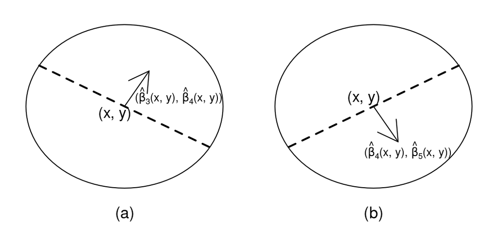

Figure 6: Neighborhood $O(x, y; h)$ of the design point $(x, y)$ is divided into two halves along the direction (a) perpendicular to $(\widehat{\beta}_3(x, y), \widehat{\beta}_4(x, y))$, (b) perpendicular to $(\widehat{\beta}_4(x, y), \widehat{\beta}_5(x, y))$.

A pixel is flagged as a roof edge point if $M(x, y) = \max\{|\widehat{f}^\prime_{x+} - \widehat{f}^\prime_{x-}|, |\widehat{f}^\prime_{y+} - \widehat{f}^\prime_{y-}| \}$ is greater than a threshold value. However, this criterion can be large around step edges too. Therefore, roof edge detection should be done only at places where there are no step edges. In DRIP, this roof edge detection method is implemented by `roofEdge`. We illustrate its use with a test image of peppers (Figure 7). The argument `edge1` specifies the step edge locations.

```r
step.edges <- stepEdge(peppers, bandwidth = 6, thresh = 25)
roof.edges <- roofEdge(peppers, bandwidth = 9, thresh = 3000,
                       step_edge = step.edges)
```

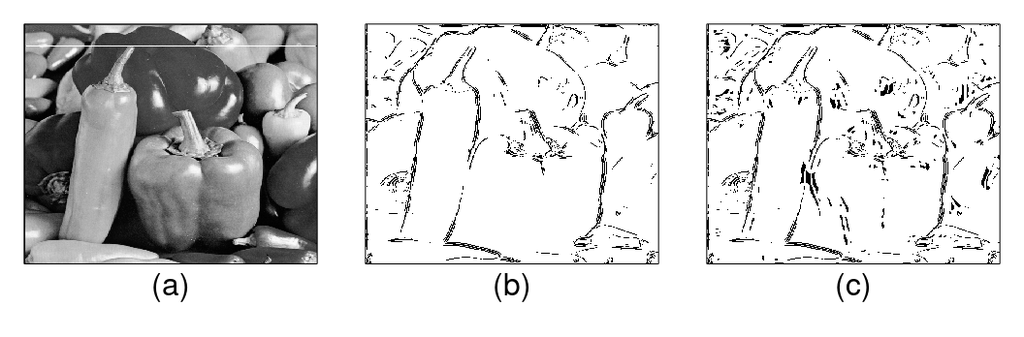

Figure 7: (a) A test image of peppers. (b) The detected step edges. (c) The detected step and roof edges.

Similar to the parameter selection for step edge detection, the bootstrap method works for roof edge detection. It is implemented by the `roofEdgeParSel` function, whose usage is identical to that of `stepEdgeParSel`. The pilot selector `edgeParSelPilot` can be used via `edgeType = "roof"`. The two modification procedures can also be applied to enhance the visual appearance of the detected roof edges.

## 6 Jump-preserving surface estimation

### 6.1 A three-stage approach

In some applications, e.g., image denoising, the ultimate goal is to estimate the regression surface. Since jumps are important features that dominate human visual perception, they should be preserved by the estimation. Qiu (1998) has suggested a three-stage approach and its idea is outlined next. The first stage is to detect jumps and any reasonable jump detection procedure (e.g., the one implemented by `stepEdge`) can be used in this stage. In the second stage, at any given design point $(x, y)$, consider its neighborhood $O(x, y; h)$. Assume that the jump positions in $O(x, y; h)$ are denoted by $\{(w_r, v_r): 1 \leq r \leq m \}$. Let $(W, V)$ denote a random vector taking values over $\{(w_r, v_r) \}$. Let $\overline{w}$ and $\overline{v}$ be the sample means of $\{w_r\}$ and $\{v_r\}$, respectively. Then search for a line $a(W - \overline{w}) + b (V- \overline{v}) = 0$ such that it attains the following minimum.
$$\begin{align*}
\min_{\tilde{a}^2 + \tilde{b}^2 = 1} \mathrm{Var} \left[ \tilde{a}(W - \overline{w}) + \tilde{b}(V - \overline{v}) \right].
\end{align*}$$
The calculation of $a$ and $b$ is straightforward. We have
$$\begin{align*}
a = \sigma_{wv}, \; b = \frac{1}{2}\left(\sigma_{vv} - \sigma_{ww} - \sqrt{(\sigma_{ww} - \sigma_{vv})^2 + 4 \sigma_{wv}^2} \right),
\end{align*}$$
where $\sigma_{ww}$, $\sigma_{vv}$ and $\sigma_{wv}$ denote the sample variances of $\{w_r\}$, $\{v_r\}$, and the sample covariance of $\{(w_r, v_r) \}$, respectively. Clearly, the line $a(W - \overline{w}) + b (V- \overline{v}) = 0$ is the first principal component line of the covariance matrix of $(W, V)$. It provides a first-order approximation to the jump location curve in $O(x, y; h)$. In the third stage, observations on the same side of the principal component line as $(x, y)$ are combined in a Nadaraya-Watson kernel estimator.
$$\begin{align}
\tag{8}
\widehat{f}(x, y) = \frac{\sum_{(x_i, y_j) \in \tilde{O}(x, y; h)} Z_{i, j} K_{i, j}}{\sum_{(x_i, y_j) \in \tilde{O}(x, y; h)} K_{i, j}},
\end{align}$$
where $\tilde{O}(x, y; h)$ denotes the design points in $O(x, y; h)$ that are on the same side of the principal component line as $(x, y)$. That is, let $\zeta_{i, j} = a\left(x_i - \overline{w} \right) + b \left(y_j - \overline{v} \right)$, and
$$\begin{align*}
\tilde{O}(x, y; h) = \begin{cases}
\left\{(x_i, y_j) \in O(x, y; h): \zeta_{i, j} \geq 0 \right\}, & \text{ if } a\left(x - \overline{w} \right) + b \left(y - \overline{v} \right) \geq 0; \\
\left\{(x_i, y_j) \in O(x, y; h): \zeta_{i, j} < 0 \right\}, & \text{ if } a\left(x - \overline{w} \right) + b \left(y - \overline{v} \right) < 0.
\end{cases}
\end{align*}$$
If there are no detected jump points in $O(x, y; h)$, then $\tilde{O}(x, y; h)$ is $O(x, y; h)$. This three-stage approach is implemented by `threeStage`, as illustrated below. The detected step edges are supplied using the argument `edge1`. Notably, users can also input the detected roof edges using the argument `edge2`. In cases where $O(x, y; h)$ contains roof edge points, a principal component line is fitted to approximate the roof edge curve and (8) is defined similarly using the observations on the same side of the fitted principal component line. If $O(x, y; h)$ contains both step and roof edge points, a principal component line would be fitted using the step edge points only and roof edge points are ignored. This is because step edges dominate human visual perception in comparison with roof edges. The idea of incorporating roof edge features in (8) was proposed in Qiu and Kang (2015), as an improvement of the approach initially suggested by Qiu (1998). The resulting estimator preserves both step and roof edges of the image. In cases where roof edge detection is deemed unnecessary, users can simply provide a matrix of zeros to `edge2`. Figure 8(a) shows the estimated SAR image after applying `threeStage`. It can be seen that the estimation preserves the discontinuities at places where edges have been successfully detected. At places where the edge detector fails to flag the edge points, the estimation still blurs the jumps.

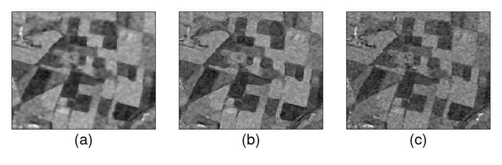

Figure 8: (a) The SAR image denoised by the three-stage approach. (b) The SAR image denoised by the gradient-based approach. (c) The SAR image denoised by the clustering-based approach.

```r
fit <- restore3Stage(image = sar, bandwidth = 4, step_edge = stepedge_m2,
                  roof_edge = array(0, dim(sar)))
```

This three-stage approach requires a bandwidth parameter. It can be selected by minimizing the following leave-one-out cross validation score.
$$\begin{align}
\tag{9}
\min_{h \in \mathscr{H}} \mathrm{CV}(h) = \frac{1}{n^2} \sum_{i, j = 1}^n \left[ Z_{i, j} - \widehat{f}_{-(i, j)}(x_i, y_j)\right]^2,
\end{align}$$
where $\mathscr{H}$ is a finite set of candidate bandwidths given by users and $\widehat{f}_{-(i, j)}$ denotes the estimator in (8) without using the $(i, j)$-th pixel. The cross validation procedure selects the bandwidth that minimizes the prediction error, as observed image intensities are readily available. In edge detection, however, there is no observed version of edges and thus cross validation cannot be utilized. Bootstrap estimates are constructed instead. It is also worth noting that, similar to the bootstrap procedure, the leave-one-out cross validation procedure is computationally expensive, as it carries out the estimation $|\mathscr{H}|$ times. The `threeStageParSel` function implements the cross validation procedure.

```r
bw_3stage <- restore3StageParSel(image = sar, bandwidth = 4:5,
                                 step_edge = stepedge_m2,
                                 roof_edge = array(0, dim(sar)))
print(bw_3stage, type = "all")
```

```
The cross validation scores:
         bandwidth=4 bandwidth=5
CV-score    294.7589    303.8463
The selected bandwidth:  4
```

### 6.2 A gradient-based approach

Although the three-stage approach is intuitively appealing, it is still complicated to use, as it requires explicit edge detection which involves careful selection of two important parameters (bandwidth and threshold). Qiu (2009) suggested a direct surface estimation approach without using any procedure parameters other than the bandwidth. Here we briefly describe its idea. As in the subsection of Step Edge Detection, $O(x, y; h)$ is divided into $O_1(x, y)$ and $O_2(x, y)$ along the direction perpendicular to the estimated gradient. Consider the local linear kernel smoothing procedures (3) and (4) and denote their solutions by $\{(\widehat{a}_k, \widehat{b}_k, \widehat{c}_k): k = 1, 2 \}$. If there are no jumps in $O(x, y; h)$, both $\widehat{a}_1$ and $\widehat{a}_2$ are consistent for estimating $f(x, y)$. If there is a single step edge in $O(x, y; h)$, either $O_1(x, y)$ or $O_2(x, y)$ should be mostly on one side of the edge, and the corresponding one-sided estimator should be able to estimate $f(x, y)$ well. In such cases, Qiu (2009) proposes to choose between $\widehat{a}_1$ and $\widehat{a}_2$ based on their weighted residual mean square of the fitted plane. Specifically, their proposed surface estimator is defined as
$$\begin{equation}
\tag{10}
\widehat{f}(x, y) = \begin{cases}
\widehat{a}_1, & \text{ if } e_1(x, y) < e_2(x, y), \\
\widehat{a}_2, & \text{ if } e_1(x, y) > e_2(x, y), \\
(\widehat{a}_1 + \widehat{a}_2)/2, & \text{ if } e_1(x, y) = e_2(x, y), \\
\end{cases}
\end{equation}$$
where $e_k(x, y) = \sum_{O_k(x, y)} \left\{ Z_{i, j} - \left[\widehat{a}_k + \widehat{b}_k(x_i - x) + \widehat{c}_k(y_j - y) \right] \right\}^2 K_{i, j}/(\sum_{O_k(x, y)} K_{i, j})$ with $k = 1, 2$. The surface estimator in (10) can be obtained by function `JPLLK_surface`. The resulting image after applying it to the SAR image is shown in Figure 8(b). It is worth noting that a numeric vector of positive integers can be supplied to the `bandwidth` argument. The one with the smallest leave-one-out cross validation score, which is similarly defined as in (9), is chosen for fitting the regression surface. The function returns a list of the fitted surface, residuals, selected bandwidth and estimated noise level. Here the residuals are defined as
$$\begin{align}
\tag{11}
\widehat{\varepsilon}_{i, j} = Z_{i, j} - \widehat{f}(x_i, y_j), \; i, j = 1, \ldots, n.
\end{align}$$
The residuals used in the bootstrap procedure in the subsection of Step Edge Detection are based on (11). The noise level $\sigma$ is estimated by $\widehat{\sigma} = (\sum_{i, j = 1}^n \widehat{\varepsilon}_{i, j}^2/n^2)^{1/2}$.

```r
fit_gb <- JPLLK_surface(image = sar, bandwidth = 3:7)
print(fit_gb, type = "bandwidth")
```

```
The selected bandwidth:  6
```

### 6.3 A clustering-based approach

The surface estimation approaches introduced in the previous two subsections work well at places where the jump location curve is smooth. This is because both approaches approximate the jump curve locally using a straight line. At places where the jump location curve has corners or cusps, such approximations may be inadequate. To address this limitation, Kang et al. (2018) proposed a clustering-based approach, described as follows. Consider the local linear kernel smoothing procedure (2). The resulting estimator, $\widehat{a}(x, y)$, is good at removing noise but also blurs the edges. Center weighted median filtering (Ko and Lee 1991; Sun et al. 1994) is a robust smoothing method in image processing and thus less sensitive to jumps in the regression surface. Apply the median filter with center weight $W_{0, 0}$ to observations in $O(x, y; h)$ and denote its output by $\tilde{a}(x, y)$. Define
$$\begin{align*}
\Delta(x, y) = \widehat{a}(x, y) - \tilde{a}(x, y).
\end{align*}$$
If $O(x, y; h)$ is in a continuity region, then the regression surface in $O(x, y; h)$ should be approximated well by the fitted plane described by $(\widehat{a}(x, y), \widehat{b}(x, y), \widehat{c}(x, y))$. As a result, $| \Delta(x, y) |$ should be small. If $O(x, y; h)$ contains a step edge, the fitted local plane cannot describe the regression surface in $O(x, y; h)$ well. Consequently, $| \Delta(x, y) |$ should be large. In other words, $| \Delta(x, y) |$ contains the jump information about $f$. Kang et al. (2018) has shown that, under the null hypothesis that $f$ is continuous at $(x, y)$,
$$\begin{align*}
n h\left[ \widehat{a}(x, y) - \tilde{a}(x, y) \right] \stackrel{d}{\rightarrow} N(0, \Sigma_{11} + \Sigma_{22} - 2\Sigma_{12}),
\end{align*}$$
where
$$\begin{align*}
\Sigma_{11} = \sigma^2 \int\int_{\mathbb{R}^2} K(x, y)^2 \; dxdy, \; \Sigma_{12} = \frac{\mathrm{E}|\varepsilon_{1, 1}|}{2\pi \phi(0)}, \; \Sigma_{22} = \frac{1}{4\pi \phi(0)^2},
\end{align*}$$
$\phi(\cdot)$ is the density function of $\varepsilon_{1, 1}$, and $\stackrel{d}{\rightarrow}$ denotes convergence in distribution. Therefore, we flag $(x, y)$ as a jump point if
$$\begin{align}
\tag{12}
\left| \Delta(x, y) \right| > q_{1 - \alpha} \sqrt{\frac{\Sigma_{11} + \Sigma_{22} - 2\Sigma_{12}}{nh}},
\end{align}$$
where $q_{1 - \alpha}$ denotes the $100( 1- \alpha)$ percentile of the standard normal distribution and $\alpha \in (0, 1)$ is the significance level. In cases where (12) holds, the estimation needs to accommodate the jump structure. Kang et al. (2018) has proposed to cluster the pixels in $O(x, y; h)$ into two groups based on their center weighted filtering outputs. Intuitively, pixels on the same side of the edge curve have similar filtering outputs. Hence, they can be put in the same group. Pixels on different sides of the edge curve have quite different filtering outputs, and they should be put in different groups. Clearly, it is not easy to specify the exact position of the edge curve within $O(x, y; h)$ and define the two groups of pixels accordingly. Nonetheless, an informative pixel clustering procedure can generate groups such that pixels within a group are similar in their filtering outputs and pixels in different groups have quite different filtering outputs. Such a pixel clustering procedure can reflect the local edge structure well without imposing restrictive conditions on the smoothness or shape of the edge curve. Specifically, define
$$\begin{align*}
O_{1, c}(x, y) &= \left\{ (x_i, y_j) \in O(x, y; h): \tilde{a}(x_i, y_j) \leq c \right\}, \\
O_{2, c}(x, y) &= O(x, y; h) \backslash O_{1, c}(x, y), %\left\{ (x_i, y_j) \in O(x, y): \tilde{a}(x_i, y_j) > c \right\},
\end{align*}$$
where $c$ is a cut-off constant and it is in the range
$$\begin{align*}
\left(\min_{(x_i, y_j) \in O(x, y; h)} \tilde{a}(x_i, y_j), \max_{(x, y) \in O(x, y; h)} \tilde{a}(x_i, y_j) \right).
\end{align*}$$
The constant $c$ is chosen to maximize the following clustering criterion
$$\begin{align}
\tag{13}
\frac{|O_{1, c}(x, y)| \left( \overline{\nu}_1 - \overline{\nu} \right)^2 + |O_{2, c}(x, y)| \left( \overline{\nu}_2 - \overline{\nu} \right)^2}{\sum_{(x_i, y_j) \in O_{1, c}(x, y)} \left( \tilde{a}(x_i, y_j) - \overline{\nu}_1 \right)^2 + \sum_{(x_i, y_j) \in O_{2, c}(x, y)} \left( \tilde{a}(x_i, y_j) - \overline{\nu}_2 \right)^2},
\end{align}$$
where $\overline{\nu}_s$ denotes the sample mean of the center weighted filtering outputs within $O_{s, c}(x, y)$ for $s = 1, 2$, and $\overline{\nu}$ denotes the sample mean of the filtering outputs within $O(x, y; h)$. In (13), the numerator quantifies the dissimilarity between the two groups, and the denominator quantifies the dissimilarity within each of the two groups. Thus, it is reasonable to cluster the pixels by maximizing their ratio. It can be shown that (13) is the one-dimensional version of the clustering criterion suggested by Friedman and Rubin (1967). Notably, there are only finitely many cut-off constants that can result in different partitions. Thus, it is sufficient to evaluate (13) on the finite set of $\{\tilde{a}(x_i, y_j): (x_i, y_j) \in O(x, y; h) \}$ and the maximization can be solved by exhaustive search. This is illustrated in Figure 9. It can be seen that the values of $\{\tilde{a}(x_i, y_j) \}$ indirectly indicate the local edge structure.

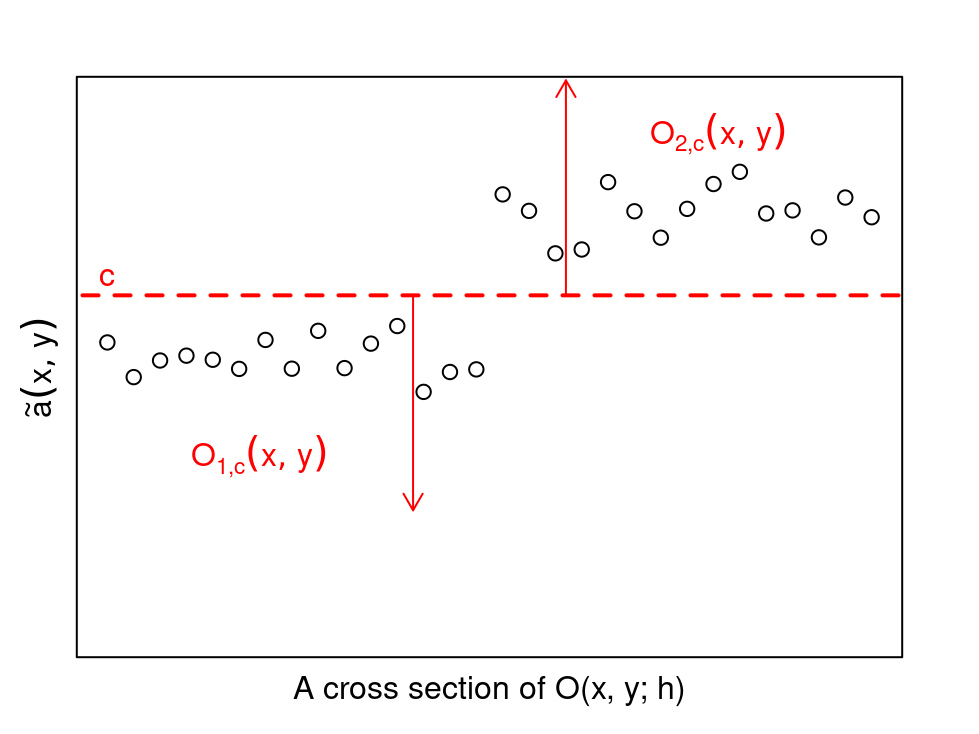

Figure 9: An illustration of local pixel clustering.

```r
fit_cl <- surfaceCluster(image = sar, bandwidth = 3, sig.level = 0.7, cw = 3)
```

```r
parSel_cluster <- surfaceCluster_bandwidth(image = sar, bandwidths = 3:4,
                                           sig.level = 0.7, cw = 3)
print(parSel_cluster, type = "all")
```

```
The cross validation scores:
  bandwidths       cv
1          3 267.9241
2          4 284.7558
The selected bandwidth:  3
The estimated sigma:  16.80083
The estimated value of the density at 0:  0.4199855
The estimated mean of absolute error:  0.776125
```

### 6.4 Comparison with other denoising methods

We compare with two other denoising algorithms available in **R**. The first is the adaptive weights smoothing (AWS) suggested by Polzehl and Spokoiny (2000). The AWS method is an iterative algorithm and known for its good performance in practical settings. The second is the non-local means (NL-means) method proposed by Buades et al. (2005). The NL-means filter has been shown to enjoy some nice asymptotic properties. Both AWS and NL-means have been implemented in the package aws (Polzehl et al. 2020; Polzehl and Tabelow 2023).

We apply the `JPLLK_surface` function in DRIP (i.e., the gradient-based approach), and the `aws` and `nlmeans` functions in aws to the SAR image and the noisy peppers image shown in Figure 4. The denoised images are presented in Figure 10. It can be seen that the images restored by NL-means are still somewhat noisy. The AWS method has rendered the sharpest results, benefiting from the algorithm’s adaptive design. This suggests that incorporating a certain adaptive mechanism into the jump regression approach can further improve its performance.

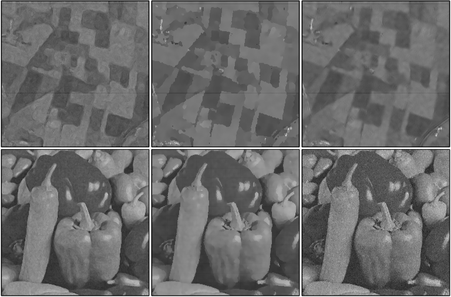

Figure 10: The denoised versions of the SAR image in Figure 1 and noisy peppers image in Figure 4 given by (from left to right) `JPLLK_surface`, `aws` and `nlmeans`, respectively.

```r
sarhat_aws <- aws(sar, hmax = 8)
fit_gb <- JPLLK_surface(image = sar, bandwidth = 3:7)
sarhat_nlm <- nlmeans(sar, lambda = 0.85, sigma = fit_gb$sigma, patchhw = 3,
                     searchhw = 3)
par(mfrow = c(2, 3), mar = c(0.1, 0.1, 0.1, 0.1), xaxt = "n", yaxt = "n")
image(fit_gb$fitted, col = gray(c(0:255)/255), zlim = range(sar))
image(sarhat_aws@theta, col = gray(c(0:255)/255), zlim = range(sar))
image(sarhat_nlm$theta, col = gray(c(0:255)/255), zlim = range(sar))
set.seed(42)
noise <- matrix(rnorm(prod(dim(peppers)), mean = 0, sd = 30),
                nrow = nrow(peppers), ncol = ncol(peppers))
peppershat_aws <- aws(peppers + noise, hmax = 8)
peppers_gb <- JPLLK_surface(image = peppers + noise, bandwidth = 3:7)
peppershat_nlm <- nlmeans(peppers + noise, lambda = 0.85, sigma = fit_gb$sigma,
                          patchhw = 3, searchhw = 3)
image(peppers_gb$fitted, col = gray(c(0:255)/255), zlim = range(peppers + noise))
image(peppershat_aws@theta, col = gray(c(0:255)/255),
      zlim = range(peppers + noise))
image(peppershat_nlm$theta, col = gray(c(0:255)/255),
      zlim = range(peppers + noise))
```

## 7 Blind image deblurring

### 7.1 A deblurring model

In addition to having noise, images may also have blur involved. For instance, in astronomical imaging, ground-based imaging systems are subject to blurring due to the rapidly changing index of refraction of the atmosphere (Schulz 1993; Krist 1995). In photography, out-of-focus or camera shake often results in blurred images (Fergus et al. 2006). In medical imaging, blurred x-rays or mammograms are almost inevitable because the medical imaging systems limit the intensity of the incident radiation in order to protect the patient’s health (Faulkner et al. 1989). In the image processing literature, a commonly used model to describe the relationship between the original image and its observed but blurred version is
$$\begin{align}
\tag{15}
Z(x_i, y_j) = G\{f\}(x_i, y_j) + \varepsilon_{i, j},
\end{align}$$
where $G\{f\}$ is the convolution between $g$ and $f$ defined by
$$\begin{align*}
G\{f\}(x,y) = g\otimes f(x, y) = \int\int_\Omega g(x-u,y-v; x, y) f(u,v)\; dudv.
\end{align*}$$
Here $g$ is called the point spread function. It describes how the original image is spatially degraded (i.e., blurred). In most references, it is further assumed that the blurring is location (or spatially) invariant. That is, $g(u, v;x, y)$ does not depend on $(x, y)$. It can be seen that model (15) includes model (1) as a special case when the point spread function is a two-dimensional Dirac delta function with a point mass at the origin.

Blind image deblurring is for estimating $f$ from $Z$ when the point spread function $g$ is not completely specified. This problem is ill-posed in nature because it is impossible to distinguish $(g,f)$ from $(ag, a^{-1}f)$ based on the observed image $Z$ alone, for any constant $a\neq 0$. Most existing blind image deblurring methods have been developed under the assumption that the point spread function $g$ does not depend on location because the ill-posed nature of the deblurring problem would be exacerbated if the blur is spatially varying, making the problem significantly more challenging. In practice, however, this assumption is often invalid. In photography, for instance, realistic camera shake includes both translations and in-plane rotations (Levin et al. 2011). Such blurring cannot be accurately described by a location-invariant point spread function. Kang (2020) has suggested a deblurring procedure without assuming a location-invariant point spread function. Their approach, which is implemented in DRIP, is described in the next subsection.

### 7.2 Image deblurring using JPEX

In image processing, it is common to assume that the blurring preserves average brightness, i.e., the point spread function $g(\cdot, \cdot; x,y)$ is a bivariate density function for each $(x,y)$. To understand the ill-posed nature of the deblurring problem, consider a special case in the one-dimensional version of (15)
$$\begin{align*}
\eta = g_0 \otimes f_0(\xi),
\end{align*}$$
where $g_0(\zeta)=I(|\zeta| \leq s)/(2s)$, $s>0$ and $f_0(\xi)=I(\xi>0)$. In this ideal case, the observations $\{(\xi_i, \eta_i): i=1,\ldots, n \}$ contain no noise, there is a jump in $f_0$, and the point spread function $g_0$ is corresponding to the one-dimensional out-of-focus blur with blurring extent $s$. By some straightforward calculation, we have
$$\begin{align*}
\eta(\xi) &= \begin{cases}
0, & \text{ if } \xi < -s, \\
\frac{1}{2s} (\xi + s), & \text{ if } -s \leq \xi \leq s \\
1, & \text{ if } \xi > s. \end{cases}
\end{align*}$$
Clearly, $\eta$ is a piece-wise linear and continuous function. Without prior knowledge about $s$, it is impossible to distinguish the truth $(g_0, f_0)$ from the no-blur solution $(\delta_0, \eta)$ based on the observations $\{(\xi_i, \eta_i): i=1,\ldots, n \}$ alone, where $\delta_0(\cdot)$ denotes the Dirac delta function with the point mass at $0$. It is also noteworthy that, because of its brightness-preserving property, the blurring does not alter $f_0(\xi)$ at places away from the jump location, where $f_0$ is flat. That is, $\eta(\xi)=f_0(\xi)$ for $\xi<-s$ or $\xi>s$. Therefore, the truth $f_0$ becomes estimable if we constrain the solution to the deblurring problem to be piece-wise constant, as non-zero gradients can only be caused by blurred jump structure in $f_0$. Motivated by this observation, Kang (2020) has proposed to impose the piece-wise constant constraint when estimating $f$ in (15). Specifically, it is assumed that $f$ is constant on each design space partition $\Omega_l$ for $l=1, \ldots, L$. Let $\rho(x,y)$ denote the blurring extent at the pixel location $(x,y)$ defined by
$$\begin{align*}
\rho(x,y) &=\inf\{r>0: supp\; g(\cdot, \cdot; x,y) \subseteq O(x,y; r) \},
\end{align*}$$
where $supp$ denotes the function’s support and $O(x,y;r) = \{(u,v): (u-x)^2+(v-y)^2 \leq r^2 \}$. The method suggested by Kang (2020) assumes that $\rho(x,y) \equiv \rho$ but allows $g(u,v;x,y)$ to have different forms as $(x,y)$ changes. Let $D=\{(x_i, y_j)\in \Omega, d_E((x_i,y_j), S)\leq \rho \}$. Obviously, $D$ is a collection of pixels that are no more than one blurring extent away from the jump location curves. Thus, their observed intensities are altered by blur and these pixels are called *blurry* pixels. With the brightness-preserving property and the piece-wise constant constraint, pixels outside $D$ (i.e., $(x_i, y_j)\in D^C$) are not affected by blur and they are called *sharp* pixels. The two kinds of pixels need to be handled differently. The key idea in Kang (2020) is to remove blur involved in blurry pixels using nearby sharp pixels.

For any given point $(x,y) \in \Omega$, consider its neighborhood $O(x, y; h)$, and fit the following local constant kernel smoothing and local linear kernel smoothing procedures:
$$\begin{align}
& \min_{\beta_0} \sum_{i,j=1}^n \left[ Z_{ij} - \beta_0 \right]^2 K_{ij}, \tag{16} \\
& \min_{\beta_0, \beta_1, \beta_2} \sum_{i,j=1}^n \left[ Z_{ij} - \beta_0 -\beta_1(x_i-x) - \beta_2(y_j-y) \right]^2 K_{ij} \tag{17}.
\end{align}$$
Let $\widehat{\beta}^{(0)}_0(x,y)$, and ($\widehat{\beta}^{(1)}_0(x,y)$, $\widehat{\beta}^{(1)}_1(x,y)$, $\widehat{\beta}^{(1)}_2(x,y)$) denote the solution to the minimization problem (16) and (17), respectively. Since $(\widehat{\beta}^{(1)}_1(x,y)$, $\widehat{\beta}^{(1)}_2(x,y))$ estimates the gradient of $G\{f\}$ at $(x,y)$, its magnitude should be relatively small if $(x, y)$ is a sharp pixel. Based on this intuition, the null hypothesis that
$$\begin{align}
\tag{18}
\mathbf{d}\left(G\{f\}\right)(x,y) &= (\partial_x G\{f\}(x,y), \partial_y G\{f\} (x,y))=(0,0)
\end{align}$$
can be tested using the following $F$ statistic
$$\begin{align*}
F_L(x,y) = \frac{\left(\text{WRSS}_0(x,y) - \text{WRSS}_1(x,y)\right)/2}{\widetilde{\sigma}_n^2},
\end{align*}$$
where $\widetilde{\sigma}_n^2$ is a consistent estimate for $\sigma^2$, $\text{WRSS}_0(x,y)$ and $\text{WRSS}_1(x,y)$ denote the weighted residual sum of squares from (16) and (17), respectively. More specifically,
$$\begin{align*}
\text{WRSS}_0(x,y) & = \sum_{i,j=1}^n \left[ Z_{ij} - \widehat{\beta}^{(0)}_0(x,y) \right]^2 K_{ij}, \\
\text{WRSS}_1(x,y) & = \sum_{i,j=1}^n \left[ Z_{ij} - \widehat{\beta}^{(1)}_0(x,y) - \widehat{\beta}^{(1)}_1(x,y) (x_i-x) - \widehat{\beta}^{(1)}_2(x,y) (y_j-y) \right]^2 K_{ij}, \\
\widetilde{\sigma}_n^2 &= \frac{1}{n^2} \sum_{i,j=1}^n \left[ Z_{ij} - \widehat{\beta}_0^{(1)}(x_i, y_j) \right]^2.
\end{align*}$$
Here $\widetilde{\sigma}^2_n$ is different from $\widehat{\sigma}^2$ in Section 4 and Section 5. It is directly based on the conventional local linear kernel smoothing, whereas $\widehat{\sigma}^2$ is based on jump-preserving surface estimation. This is because the blurred regression surface $G\{f\}(x, y)$ is continuous and thus the residuals from (17) are appropriate representations of the random errors. This was not the case with jump regression problems in the previous two section.

```r
data("stopsign", package = "DRIP")
deblur <- jpex(image = stopsign, bandwidth = 2, sigma = 0.00623, alpha = 0.001)
names(deblur)
```

```
[1] "deblurred" "edge"
```

For comparison, in Figure 11(d) we also include the result given by the unsupervised Wiener-Hunt deconvolution function in scikit-image. It is a Bayesian method suggested by Orieux et al. (2010) that performs joint estimation of the point spread function and underlying image. It can be seen that the restored image still contains blur and has some ringing artifacts.

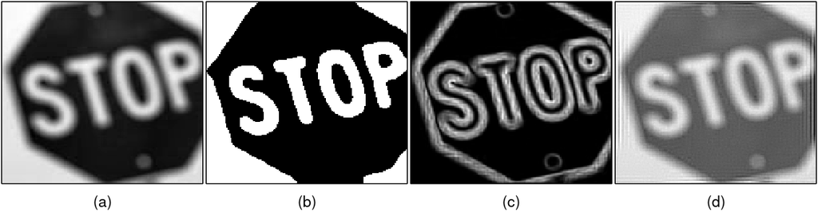

Figure 11: (a) The image of a blurry stop sign. (b) The deblurred image given by `jpex`. (c) The blurry pixels flagged by `jpex`. (d) The deblurred image given by **scikit-image**.

```r
if (reticulate::py_module_available("skimage")) {
  skimage <- reticulate::import("skimage")
} else {
  message("Python module 'scikit-image' is required and being installed.")
  reticulate::py_install("scikit-image", pip = TRUE)
  skimage <- reticulate::import("skimage")
}
np <- import("numpy")
restoration <- import("skimage.restoration")
psf0 <- np$ones(c(3L, 3L)) / 9
result <- restoration$unsupervised_wiener(stopsign, psf = psf0)
pyout <- result[[1]]
```

### 7.3 Bandwidth selection in JPEX

```r
cv.out <- cv.jpex(image = stopsign, bandwidths = c(2, 3), ncpus = 2)
print(cv.out, type = "all")
```

```
The cross validation scores:
[1] 5.591376e-05 1.421656e-04
The selected bandwidth:  2
The estimated sigma:  0.006231292
```

## 8 Workflow illustration

The workflow of using functions in DRIP often involves tuning some parameters first and then estimating the image features. Here we illustrate this process using edge-preserving noise removal of the SAR image as an example. Specifically, in the edge detection step, the edge detector `stepEdge` requires a bandwidth parameter and a threshold value. We first establish an initial range for the parameters. The visualization provided by the `edgeParSelPilot` function is useful for this purpose.

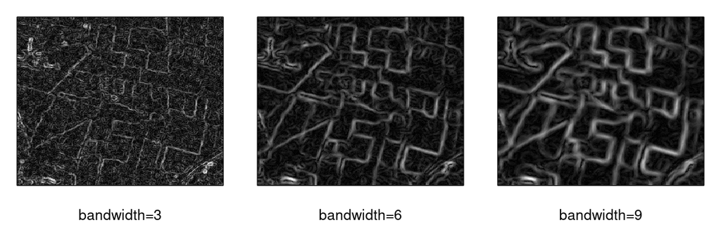

Figure 12: The images of the step edge detection statistics with the specified bandwidth values.

```
            probs=0.75 probs=0.8 probs=0.9 probs=0.95
bandwidth=3   15.82019  17.36624  22.11585   26.87138
bandwidth=6   13.31046  15.28433  21.32755   26.51575
bandwidth=9   14.72569  16.76905  22.61165   27.09358
```

```r
edgeParSelPilot(sar, edgeType = "step", degree = 0,
                bandwidth = c(3, 6, 9), probs = c(0.75, 0.8, 0.9, 0.95))
```

It can be seen from Figure 12 that the bandwidth value of $3$ seems too small (the corresponding image is still noisy). The bandwidth value of $9$ appears to be too large (minor edges are lost in the resulting image). Therefore, bandwidth values around $6$ are reasonable choices. Next, we determine the initial range for the threshold parameter. Based on the upper quantiles of the detection statistics with bandwidth $6$, threshold values around $15$ are good starting points. Next, we can finalize our parameter selection using the function `stepEdgeParSel`.

```r
set.seed(24)
bandthresh <- stepEdgeParSel(sar, bandwidth = 4:5, thresh = 15:16,
                             nboot = 10, degree = 0)
edge1 <- stepEdge(sar, bandwidth = bandthresh$bandwidth,
                  thresh = bandthresh$threshold, degree = 0)
```

With the selected bandwidth and threshold, we have detected the step edges in the SAR image (shown in Figure 13. In the noise removal step, we apply the three-stage approach described earlier. Since the three-stage approach also requires a bandwidth parameter, we determine its value by cross validation (CV) before estimating the image. The denoised image is shown in Figure 13 and this completes the workflow.

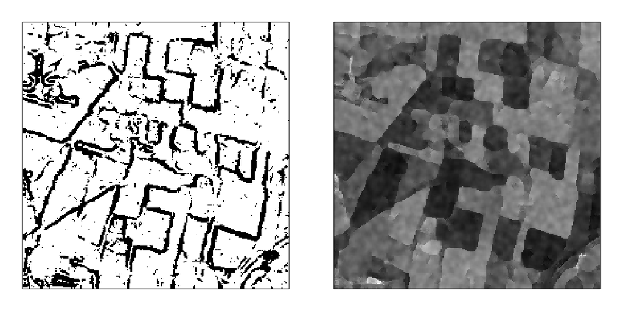

Figure 13: The detected step edges using the bootstrap-selected bandwidth and threshold values (left). The denoised SAR image using the CV-selected bandwidth (right).

```r
cv3stage <- restore3StageParSel(sar, bandwidth = 4:9, step_edge = edge1,
                             roof_edge = array(0, dim(sar)))
sar_out <- restore3Stage(sar, bandwidth = cv3stage$bandwidth,
                       step_edge = edge1, roof_edge = array(0, dim(sar)))
par(mfrow = c(1, 2), mar = c(1, 1, 1, 1), xaxt = "n", yaxt = "n")
image(1 - edge1, col = gray(c(0:1)))
image(sar_out, col = gray(c(0:255)/255))
```

## 9 Concluding remarks

We have described DRIP, an R package that implements a number of jump regression methods with an emphasis on image processing applications. The package provides functions for step edge detection, roof edge detection, image denoising, image deblurring and the related data-driven parameter selection. Much of DRIP’s source code is written in Fortran or C to achieve good computational performance. Its R interface enables easy adoption and adaptation of the methods. It is intended to further broaden the scope of the package in the future. In particular, jump regression-based image registration (Qiu and Xing 2013) has been an active research area. Including those routines in the package is certainly an interesting direction to pursue. Adding methods for image comparison (Feng and Qiu 2018) and image monitoring (Kang 2022, 2023) is also planned for the future.

### 9.1 CRAN packages used

adimpro, aws, OpenImageR, Rcpp, dti, landsat, DRIP

### 9.2 CRAN Task Views implied by cited packages

HighPerformanceComputing, MedicalImaging, NumericalMathematics, Spatial

### 9.3 Bioconductor packages used

EBImage

Y. Bai, G. Cheung, X. Liu and W. Gao. Graph-based blind image deblurring from a single photograph. *IEEE Transactions on Image Processing*, 28(3): 1404–1418, 2018. DOI TIP.2018.2874290.

S. Boonprong, C. Cao, W. Chen, X. Ni, M. Xu and B. K. Acharya. The classification of noise-afflicted remotely sensed data using three machine-learning techniques: Effect of different levels and types of noise on accuracy. *International Journal of Geo-Information*, 7(7): 2018. DOI 10.3390/ijgi7070274.

G. Bradski and A. Kaehler. *Learning OpenCV: Computer vision with the OpenCV library.* " O’Reilly Media, Inc.", 2008. URL https://opencv.org/.

A. Buades, B. Coll and J.-M. Morel. A review of image denoising algorithms, with a new one. *Multiscale modeling & simulation*, 4(2): 490–530, 2005. DOI 10.1137/040616024.

J. Fan and I. Gijbels. *Local polynomial modelling and its applications: Monographs on statistics and applied probability 66.* New York: Routledge, 2018. DOI 10.1201/9780203748725.

K. Faulkner, C. Kotre and M. Louka. Veiling glare deconvolution of images produced by X-ray image intensifiers. In *Third international conference on image processing and its applications*, pages. 669–673 1989. IET. URL https://ieeexplore.ieee.org/abstract/document/132213.

L. Feng and P. Qiu. Difference detection between two images for image monitoring. *Technometrics*, 60(3): 345–359, 2018. DOI 10.1080/00401706.2017.1356378.

R. Fergus, B. Singh, A. Hertzmann, S. T. Roweis and W. T. Freeman. Removing camera shake from a single photograph. In *Acm siggraph 2006 papers*, pages. 787–794 2006. ACM. DOI 10.1145/1179352.1141956.

H. P. Friedman and J. Rubin. On some invariant criteria for grouping data. *Journal of the American Statistical Association*, 62(320): 1159–1178, 1967. DOI 10.2307/2283767.

A. Georgantzoglou, J. da Silva and R. Jena. Image processing with MATLAB and GPU. In *MATLAB applications for the practical engineer*, 2014. IntechOpen. DOI 10.5772/58300.

I. Gijbels, A. Lambert and P. Qiu. Edge-preserving image denoising and estimation of discontinuous surfaces. *IEEE Transactions on Pattern Analysis and Machine Intelligence*, 28(7): 1075–1087, 2006. DOI 10.1109/TPAMI.2006.140.

C. A. Glasbey and G. W. Horgan. *Image analysis for the biological sciences.* Hoboken, New Jersey: John Wiley & Sons, 1995. URL https://dl.acm.org/doi/abs/10.5555/208252.

R. C. Gonzalez and R. E. Woods. *Digital image processing.* 4th ed New York, NY: Pearson, 2018. URL https://elibrary.pearson.de/book/99.150005/9781292223070.

S. Goslee. *landsat: Radiometric and topographic correction of satellite imagery.* 2023. URL https://CRAN.R-project.org/package=landsat. **R** package version 1.1.2.

S. C. Goslee. Analyzing remote sensing data in **r**: The landsat package. *Journal of Statistical Software*, 43: 1–25, 2011. DOI 10.18637/jss.v043.i04.

P. Hall and P. Qiu. Blind deconvolution and deblurring in image analysis. *Statistica Sinica*, 1483–1509, 2007. URL http://www.jstor.org/stable/24307685.

M. Hillebrand and C. H. Müller. Outlier robust corner-preserving methods for reconstructing noisy images. *The Annals of Statistics*, 35(1): 132–165, 2007. DOI 10.1214/009053606000001109.

Y. Kang. Consistent blind image deblurring using jump-preserving extrapolation. *Journal of Computational and Graphical Statistics*, 29(2): 372–382, 2020. DOI 10.1080/10618600.2019.1665536.

Y. Kang. Statistical process monitoring approaches for image data. *Wiley StatsRef: Statistics Reference Online*, 1–15, 2023. DOI 10.1002/9781118445112.stat08263.

Y. Kang. Statistical quality control using image intelligence: A sparse learning approach. *Naval Research Logistics (NRL)*, 69(7): 996–1008, 2022. DOI 10.1002/nav.22069.

Y. Kang, P. S. Mukherjee and P. Qiu. Efficient blind image deblurring using nonparametric regression and local pixel clustering. *Technometrics*, 60(4): 522–531, 2018. DOI 10.1080/00401706.2017.1415975.

Y. Kang and P. Qiu. Jump detection in blurred regression surfaces. *Technometrics*, 56(4): 539–550, 2014. DOI 10.1080/00401706.2013.844732.

Y. Kang, Y. Shi, Y. Jiao, W. Li and D. Xiang. Fitting jump additive models. *Computational Statistics & Data Analysis*, 162: 107266, 2021. DOI 10.1016/j.csda.2021.107266.

A. Klein, J. Andersson, B. A. Ardekani, J. Ashburner, B. Avants, M.-C. Chiang, G. E. Christensen, D. L. Collins, J. Gee, P. Hellier, et al. Evaluation of 14 nonlinear deformation algorithms applied to human brain MRI registration. *Neuroimage*, 46(3): 786–802, 2009. DOI 10.1016/j.neuroimage.2008.12.037.

S.-J. Ko and Y. H. Lee. Center weighted median filters and their applications to image enhancement. *IEEE Transactions on Circuits and Systems*, 38(9): 984–993, 1991. DOI 10.1109/31.83870.

J. Krist. Simulation of HST PSFs using tiny tim. In *Astronomical data analysis software and systems IV*, Eds R. A. Shaw, H. E. Payne and J. J. E. Hayes pages. 349–352 1995. URL https://adsabs.harvard.edu/full/record/seri/ASPC./0077/1995ASPC...77..349K.html.

A. Levin, Y. Weiss, F. Durand and W. T. Freeman. Understanding blind deconvolution algorithms. *IEEE Transactions on Pattern Analysis and Machine Intelligence*, 33(12): 2354–2367, 2011. DOI 10.1109/TPAMI.2011.148.

L. Mouselimis. *OpenImageR: An image processing toolkit.* 2023. URL https://CRAN.R-project.org/package=OpenImageR. R package version 1.3.0.

F. Orieux, J.-F. Giovannelli and T. Rodet. Bayesian estimation of regularization and point spread function parameters for wiener–hunt deconvolution. *Journal of the Optical Society of America A*, 27(7): 1593–1607, 2010. DOI 10.1364/JOSAA.27.001593.

G. Pau, F. Fuchs, O. Sklyar, M. Boutros and W. Huber. EBImage - an **r** package for image processing with applications to cellular phenotypes. *Bioinformatics*, 26(7): 979–981, 2010. DOI 10.1093/bioinformatics/btq046.

J. Polzehl, K. Papafitsoros and K. Tabelow. Patch-wise adaptive weights smoothing in R. *Journal of Statistical Software*, 95(6): 1–27, 2020. DOI 10.18637/jss.v095.i06.

J. Polzehl and V. G. Spokoiny. Adaptive weights smoothing with applications to image restoration. *Journal of the Royal Statistical Society: Series B (Statistical Methodology)*, 62(2): 335–354, 2000. DOI 10.1111/1467-9868.00235.

J. Polzehl and K. Tabelow. Adaptive smoothing of digital images: The R package adimpro. *Journal of Statistical Software*, 19(1): 1–17, 2007. DOI 10.18637/jss.v019.i01.

J. Polzehl and K. Tabelow. *Magnetic resonance brain imaging: Modeling and data analysis using r.* Springer, 2023. DOI 10.1007/978-3-030-29184-6.

P. Qiu. Discontinuous regression surfaces fitting. *The Annals of Statistics*, 26(6): 2218–2245, 1998. DOI 10.1214/aos/1024691468.

P. Qiu. *Image processing and jump regression analysis.* Hoboken, New Jersey: John Wiley & Sons, 2005. URL https://www.wiley.com/en-be/Image+Processing+and+Jump+Regression+Analysis-p-9780471420996.

P. Qiu. Jump surface estimation, edge detection, and image restoration. *Journal of the American Statistical Association*, 102(478): 745–756, 2007. DOI 10.1198/016214507000000301.

P. Qiu. Jump-preserving surface reconstruction from noisy data. *Annals of the Institute of Statistical Mathematics*, 61: 715–751, 2009. DOI 10.1007/s10463-007-0166-9.

P. Qiu and Y. Kang. Blind image deblurring using jump regression analysis. *Statistica Sinica*, 25: 879–899, 2015. DOI 10.5705/ss.2014.054.

P. Qiu and C. Xing. On nonparametric image registration. *Technometrics*, 55(2): 174–188, 2013. DOI 10.1080/00401706.2012.727768.

P. Qiu and B. Yandell. Jump detection in regression surfaces. *Journal of Computational and Graphical Statistics*, 6(3): 332–354, 1997. DOI 10.2307/1390737.

Y. Quan, Z. Wu, R. Xu and H. Ji. Deep single image defocus deblurring via gaussian kernel mixture learning. *IEEE Transactions on Pattern Analysis and Machine Intelligence*, 46(12): 11361–11377, 2024. DOI 10.1109/TPAMI.2024.3457856.

R Core Team. **R**: A language and environment for statistical computing. Vienna, Austria: **R** Foundation for Statistical Computing, 2023. URL https://www.R-project.org/.

T. J. Schulz. Multiframe blind deconvolution of astronomical images. *Journal of the Optical Society of America A*, 10(5): 1064–1073, 1993. DOI 10.1364/JOSAA.10.001064.

J. Sun and P. Qiu. Jump detection in regression surfaces using both first-order and second-order derivatives. *Journal of Computational and Graphical Statistics*, 16(2): 289–311, 2007. DOI 10.1198/106186007X204753.

T. Sun, M. Gabbouj and Y. Neuvo. Center weighted median filters: Some properties and their applications in image processing. *Signal Processing*, 35(3): 213–229, 1994. DOI 10.1016/0165-1684(94)90212-7.

K. Tabelow and J. Polzehl. Beyond the gaussian model in diffusion-weighted imaging: The package dti. *Journal of Statistical Software*, 44(12): 1–26, 2011. URL https://www.jstatsoft.org/v44/i12/.

K. Tabelow, J. Polzehl, V. Spokoiny and H. U. Voss. Diffusion tensor imaging: Structural adaptive smoothing. *NeuroImage*, 39(4): 1763–1773, 2008. DOI 10.1016/j.neuroimage.2007.10.024.

The MathWorks Inc. **MATLAB** version: 23.2.0 (R2023b). Natick, Massachusetts, United States: The MathWorks Inc., 2023. URL https://www.mathworks.com.

S. Van der Walt, J. L. Schönberger, J. Nunez-Iglesias, F. Boulogne, J. D. Warner, N. Yager, E. Gouillart and T. Yu. Scikit-image: Image processing in python. *PeerJ*, 2: e453, 2014. DOI 10.7717/peerj.453.

M. P. Wand and M. C. Jones. *Kernel smoothing.* Boca Raton, FL: CRC Press, 1994. DOI 10.1201/b14876.

C. Wang, L. Sun, P. Cui, J. Zhang and S. Yang. Analyzing image deblurring through three paradigms. *IEEE Transactions on Image Processing*, 21(1): 115–129, 2011. DOI 10.1109/TIP.2011.2159985.

Z. Yue, J. Wang and C. C. Loy. Efficient diffusion model for image restoration by residual shifting. *IEEE Transactions on Pattern Analysis and Machine Intelligence*, 47(1): 116–130, 2025. DOI 10.1109/TPAMI.2024.3461721.

B. Zitova and J. Flusser. Image registration methods: A survey. *Image and vision computing*, 21(11): 977–1000, 2003. DOI 10.1016/S0262-8856(03)00137-9.